# Federal Public Investment in Mexico, 1959–1963

Descriptive statistics — institutions and states (Cuadros 15–23, *Inversión Pública Federal*)

TapadosPRI

July 02, 2026

# Overview

This report summarises **federal public investment** recorded in the yearly cuadros *“Inversión de las dependencias, organismos y empresas del sector público, por entidades federativas”* for **1959–1963**. Each observation is one institution’s investment in one state in one year. All figures are reported in **real *millones de pesos*, constant 1960 prices**, deflated with the World Bank consumer price index (see below).

> **Deflation.** Nominal pesos are converted to constant 1960 pesos using the Mexican CPI (World Bank WDI), rebased so 1960 = 100. Because the series begins in 1960, fiscal year 1959 is assigned the 1960 price level. Inflation was low in this window (≈3.4% cumulative 1960→1963), so the real adjustment is modest but makes the yearly totals directly comparable and consistent with the eventual 1925–2000 panel.

> **Presidency note.** All five fiscal years fall within a single sexenio — **Adolfo López Mateos (PRI, Dec 1958 – Nov 1964)**. “By presidency” cuts below therefore describe López Mateos’ term; the code carries a general year→president map so the same tables extend automatically if earlier cuadros (back to 1925) are added.

Coverage of the extracted database

| Metric | Value |
| --- | --- |
| Years | 1959 – 1963 |
| Institutions (distinct) | 86 |
| States | 32 |
| Sectors | 4 |
| Institution × state records | 2,219 |
| Total investment (real mdp, 1960) | 38,919 |

# 1 Total federal investment by year

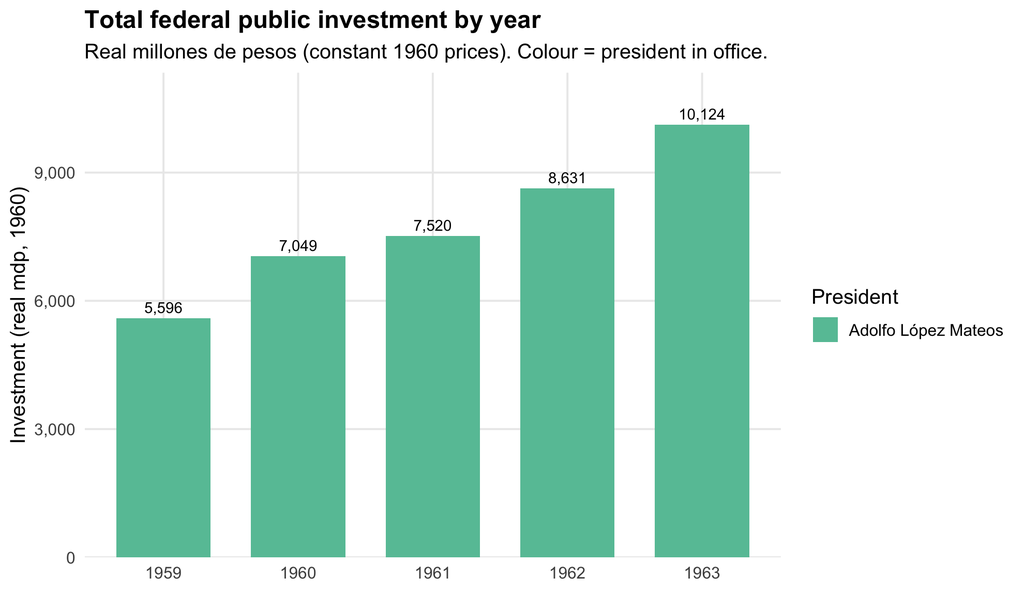

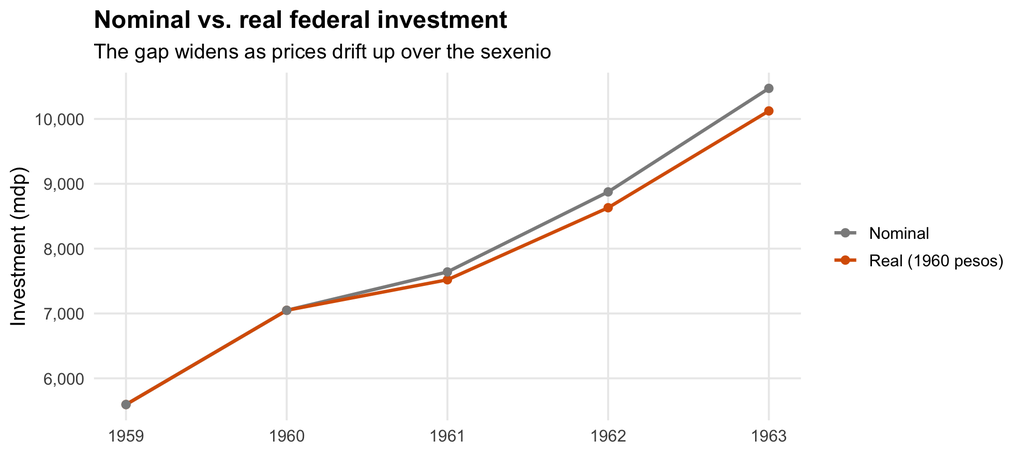

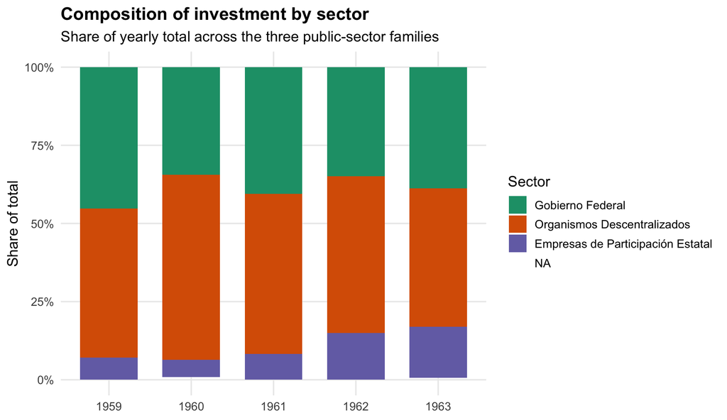

# 2 Rankings

## 2.1 Top institutions overall

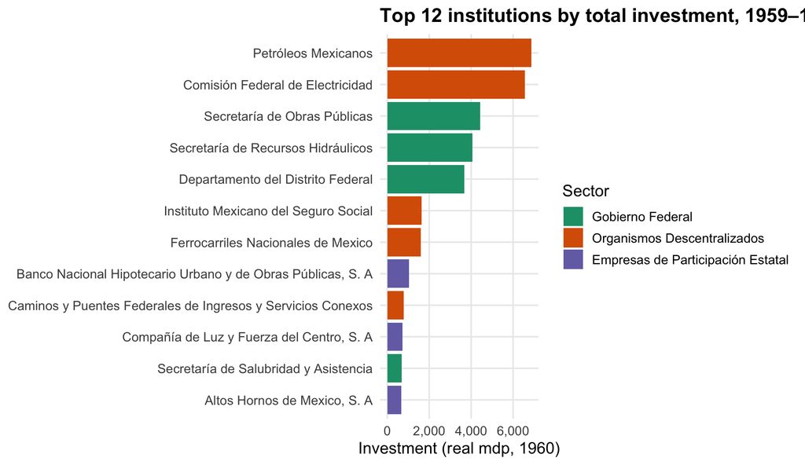

## 2.2 Top 10 states overall

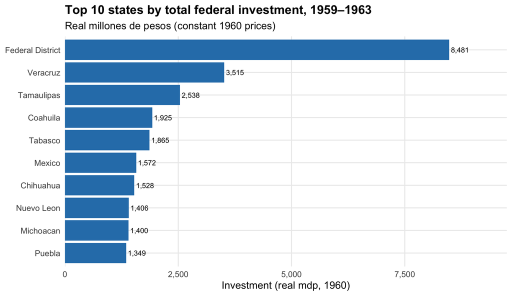

## 2.3 Top 5 states and institutions by presidency

Leading recipients and spenders by sexenio

| president | Top 5 states (real mdp) | Top 5 institutions (real mdp) |
| --- | --- | --- |
| Adolfo López Mateos | Federal District (8,481); Veracruz (3,515); Tamaulipas (2,538); Coahuila (1,925); Tabasco (1,865) | Petróleos Mexicanos (6,870); Comisión Federal de Electricidad (6,557); Secretaría de Obras Públicas (4,434); Secretaría de Recursos Hidráulicos (4,068); Departamento del Distrito Federal (3,677) |

# 3 State analysis

The volume is organised *por entidades federativas*, so the state dimension is its strongest feature. This section maps where federal money went, how concentrated it was, and how state allocations shifted across the sexenio.

## 3.1 Choropleth — where the money went

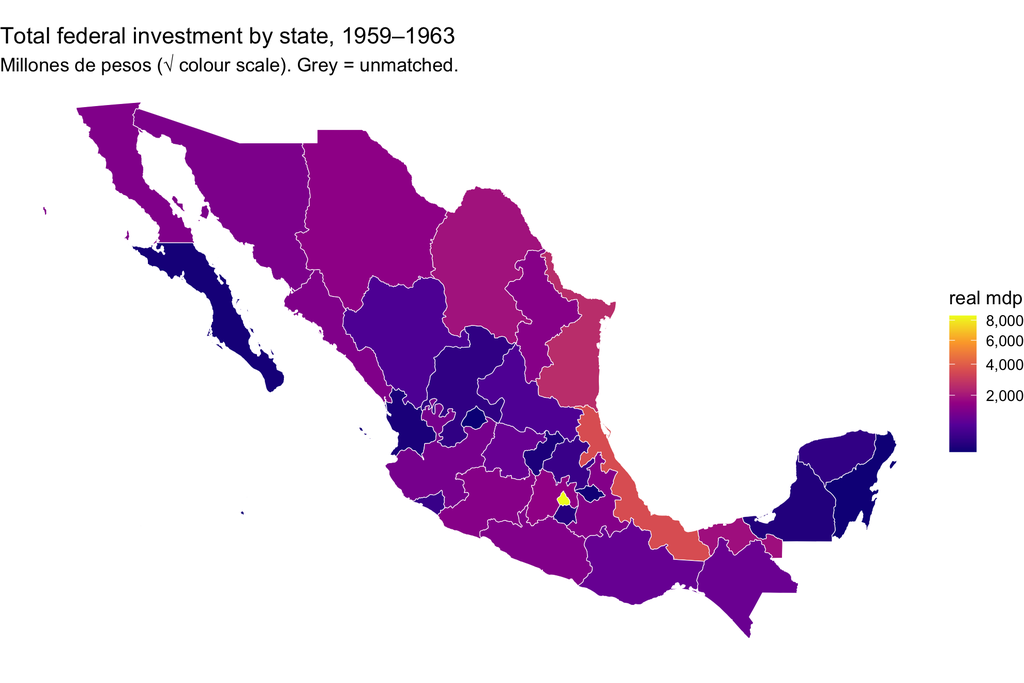

Because the **Federal District** and a few industrial states dominate, the map below drops the Federal District to reveal variation across the rest of the country.

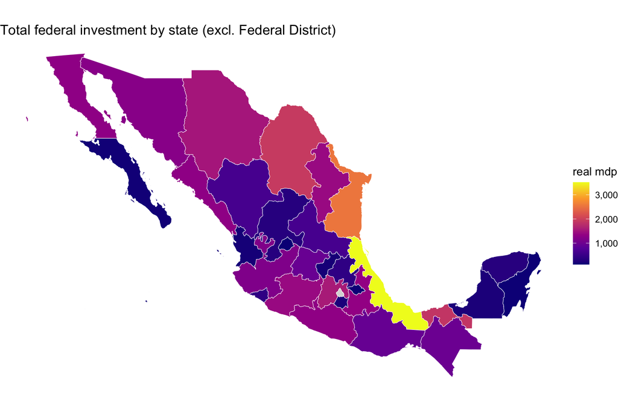

## 3.2 State × year heatmap

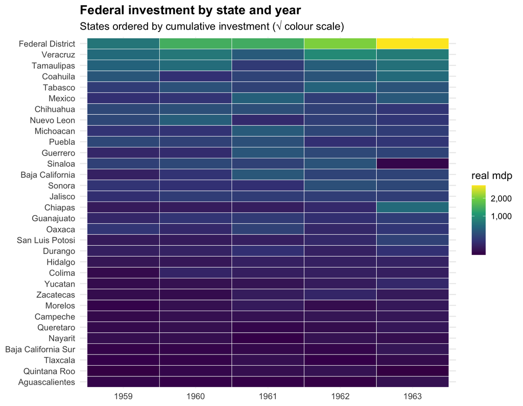

## 3.3 Sector mix by state

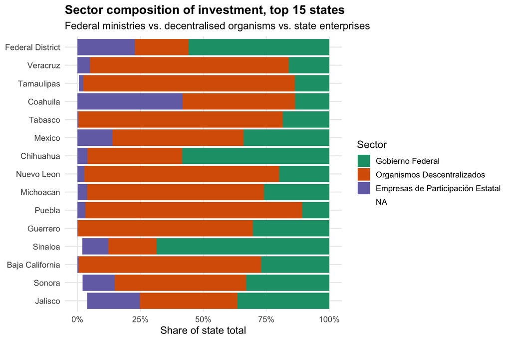

## 3.4 Growth across the sexenio

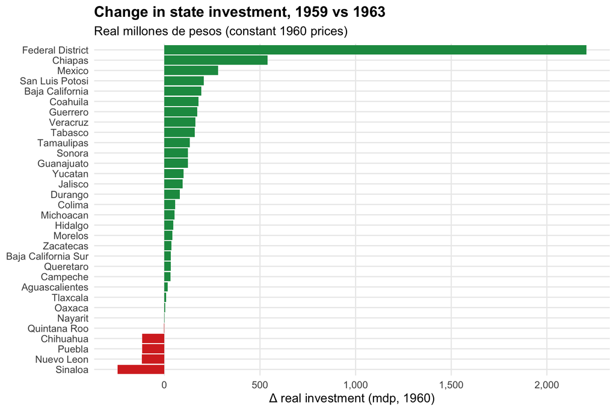

## 3.5 Concentration & inequality

Geographic concentration of federal investment

| Sample | Top-1 share | Top-5 share | HHI | Gini |
| --- | --- | --- | --- | --- |
| All states | 21.8% | 47.1% | 0.080 | 0.509 |
| Excl. Federal District | 11.5% | 37.5% | 0.053 | 0.426 |

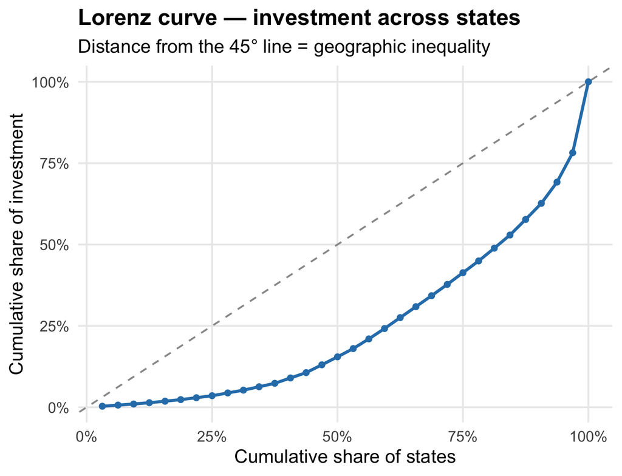

# Recommended further analysis

- **Deflator robustness.** Figures are now real (CPI, 1960 = 100). A wholesale or gross-fixed-capital-formation deflator (INEGI/Banxico) is arguably better for *investment* than the CPI and would be a useful sensitivity check; the WPI series here is empty before ~1970, so it can only anchor the later panel.
- **Per-capita and per-area allocation.** Join 1960-census state population to see whether high totals (Federal District, Coahuila) survive normalisation, or whether poorer states received more *per head* — the real distributive question.
- **Extend the panel to 1925–1963.** The full volume covers earlier cuadros; adding them turns the president lookup into a genuine cross-sexenio comparison (Cárdenas → Ávila Camacho → Alemán → Ruiz Cortines → López Mateos).
- **Volatility of allocations.** Coefficient of variation of each state’s yearly share flags politically “swing” vs. stable recipients.
- **Link to the biography networks (project payoff).** Cross the leading institutions here (SOP, SRH, PEMEX, CFE) with the `govt_positions` careers: did tapados and their network alters cluster in the highest-investment ministries? Use `total_mdp` from `federal_investment_institutions.csv` as a **budget-based institution-importance weight** for the manual rank tables in `data/rank/`.
- **Regional politics.** Aggregate to regions (North, Bajío, Centre, South-East) and test whether investment tracked governors’ alignment with the president.

```
## Data source: /Users/ezagoc/Dropbox/TapadosPRI/data/investment
## Rendered: 2026-07-02 21:41:21
```